# JHU Data Science Capstone Milestone Report

Shuai Wang

Saturday, July 25, 2015

## Introduction

This is the milestone report for the Data Science Capstone project in the Johns Hopkins University Data Science Coursera Specialization. The purpose of this project is to predict the next word for incomplete sentences. In this report, I am required to display that I’ve gotten used to working with the data and that I am on track to create my prediction algorithm. The motivation for this project is to:

1. Demonstrate that I’ve downloaded the data and have successfully loaded it in.
2. Create a basic report of summary statistics about the data sets.
3. Report any interesting findings that I amassed so far.
4. Get feedback on my plans for creating a prediction algorithm and Shiny app.

## Data Downloading and Cleaning

First, I download the data file from the coursera website and unzipp it. The data downloaded contains four language versions, and I choose English version (en_US version) to proceed. Then I get three text files collected from blogs, news, and twitter.

These files are consisted with lines, and different lines represent different documents. Those lines are far from uniform in terms of encoding and language. Some lines contain characters `R` does not recognize, and `R` even stops reading further because of some special character. Thus I have to manually remove it to fully read in all data.

Now we can calculate the number of lines contained in those files as follows:

```
##   en_US.blogs.txt    en_US.news.txt en_US.twitter.txt
##            899288           1010242           2360148
```

So there are about one or two million lines in each text file. It is time consuming to process all of them, so I sample three smaller text files from them, and use them for my training purpose. After sampling, I also correct the encoding without loss of any information, such as replacing the latin1-encoded left and right double quotation marks by `"`. Now we count the number of lines for the three samples got. This time we can get the word counts and their distributions (symbols are not counted), as the computation power of my laptop is enough for these smaller files.

```
##                  Line.Count Min.Word.Count 1st Qu.Word.Count
## sample.blogs.txt       9193              0                 9
## sample.news.txt       10272              1                20
## sample.twits.txt      23832              2                 7
##                  Median.Word.Count Mean.Word.Count 3rd Qu.Word.Count
## sample.blogs.txt                28           42.93                61
## sample.news.txt                 32           35.48                47
## sample.twits.txt                12           13.25                19
##                  Max.Word.Count
## sample.blogs.txt            830
## sample.news.txt             260
## sample.twits.txt             65
```

It is clear that the lines in the twitter file contains fewer words than those of blogs and news, and number of words for lines in blogs vary more than those in news.

## Term Frequency Exploration

I think each text file should be treated differently, as they are in different circumstances. As the exploratory results of the three are similar, I only focus on one text file in this report, the sample blog text file.

As we still have few characters unrecognizable by `R`, I think it is safe to remove them because their percentage is small. For the symbols, I still keep them, but separate them from their attaching words. For dollar amounts, non-dollar-amount numbers and time, I unify their representations respectively, because I think keeping those numbers different does not make much sense for our purpose. I also convert all alphabetic words to lower case. Hyphens are retained if they are in the middle of words, and contracted forms are expanded. `#` is coded appropriately so a phrase like “#1” is coded as “number 1”. I have also removed the profanity words that I do not want to predict.

Notice that we haven’t removed stopwords yet. Let’s see if we need do it. Get the words with term frequencies over 400 as follows:

```
##  [1] "about"   "after"   "all"     "also"    "and"     "any"     "are"
##  [8] "back"    "because" "been"    "but"     "can"     "could"   "day"
## [15] "did"     "even"    "first"   "for"     "from"    "get"     "going"
## [22] "good"    "had"     "has"     "have"    "her"     "here"    "him"
## [29] "his"     "how"     "into"    "just"    "know"    "life"    "like"
## [36] "little"  "love"    "make"    "many"    "more"    "most"    "much"
## [43] "new"     "not"     "now"     "one"     "only"    "other"   "our"
## [50] "out"     "over"    "people"  "really"  "see"     "she"     "some"
## [57] "still"   "than"    "that"    "the"     "their"   "them"    "then"
## [64] "there"   "these"   "they"    "things"  "think"   "this"    "time"
## [71] "two"     "very"    "was"     "way"     "well"    "were"    "what"
## [78] "when"    "which"   "who"     "will"    "with"    "would"   "you"
## [85] "your"
```

The top 20 frequent words with their frequencies are listed below:

```
##   the   and  that   not   for   was   you  with  have  this   are   but
## 19274 11244  4691  3842  3762  3152  3109  2969  2774  2687  2420  2075
##  they  from   all  will   one   can about   his
##  1572  1553  1529  1509  1279  1267  1216  1174
```

Look at the distribution of the term frequencies as follows:

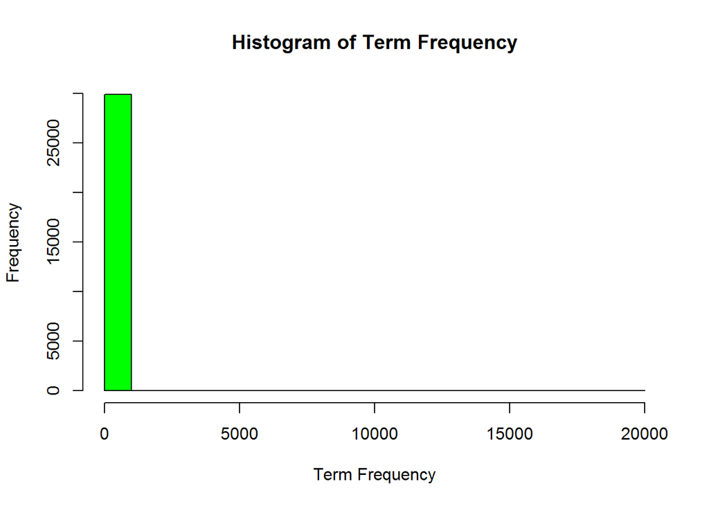

So we can see that some certain words occur extremely frequently, like “the” and “and”, and most of the words have relatively low frequencies. However, those frequent words may be helpful in our prediction, as the next word to be predicted might be “the” or “and”, or some other frequent words. But now, for our exploration, we might want to remove those stopwords and see what happens. I also remove the punctuations, but I do not stem the words yet.

Now the words with term frequencies over 400 become:

```
##  [1] "also"   "back"   "can"    "day"    "even"   "first"  "get"
##  [8] "going"  "good"   "just"   "know"   "life"   "like"   "little"
## [15] "love"   "make"   "many"   "much"   "new"    "now"    "one"
## [22] "people" "really" "see"    "still"  "things" "think"  "time"
## [29] "two"    "way"    "well"   "will"
```

And the top 20 frequent words with their frequencies after stopword removal are:

```
##   will    one    can   time   just   like    get   know people    now
##   1509   1286   1267   1066   1014    996    712    643    618    616
##    new   make   well   also   even  first    see   back really    day
##    545    538    534    531    529    526    523    516    509    506
```

The distribution of the term frequencies this time is:

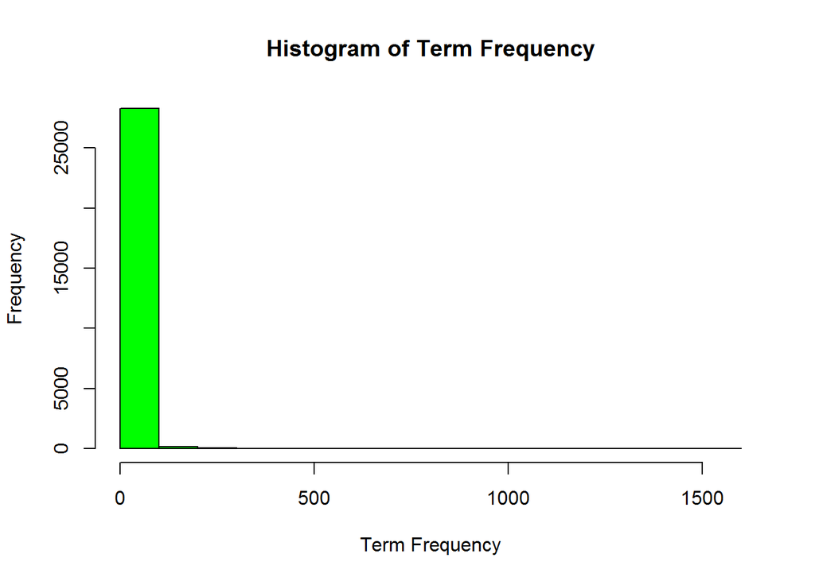

We can see that the distribution is still skewed. We may include more words as stopwords in the further exploration. But I don’t want to do it now. I want to directly calculate the frequency for some randomly chosen not-that-frequent word, say “bacon”. After computation, its frequency in my sample blog dataset is 11. So it very seldomly occurs, considering our sample blog data contains about 10,000 lines, and each line contains dozens of words in average.

Therefore, we have such a low frequency even for a not-so-rare word. Given such a low frequency, how can I do statistical prediciton based on it? Not to speak of n-grams. One way to address it is to do stemming. So I have also tried it, and I get `13` as its frequency, not a big improvement. Another way to address it is to increase the sample size. I have tried my analysis on one of the three original text files, and it takes hours to run even for counting the words. So my next step is to increase the sampling probability to get a tradeoff between term frequency and computation power. Or is there any one of you who can help me to get free access to cloud computing? Then I can work on more data and get a more accurate prediction. I also need help with working with n-grams, as I don’t know how to do it. Currently I am using the `tm` package in `R`. I am new to it, and I don’t know if there is any such feature there.

## Term Association Exploration

Although we have low sample size problem and the result may be unreliable in theory, we can still explore word associations. Still take “bacon” as an example, the following are the words whose correlations with “bacon” are above `0.2`:

```
##      bacon.barbeque          bacon.hock    bacon.depressing
##                0.69                0.69                0.40
##         bacon.beans         bacon.dunno     bacon.appealing
##                0.38                0.34                0.31
##      bacon.prospect       bacon.avovado         bacon.calas
##                0.28                0.23                0.23
##     bacon.carbonara          bacon.cdog   bacon.chronically
##                0.23                0.23                0.23
##        bacon.crazes      bacon.creamier          bacon.degr
##                0.23                0.23                0.23
##        bacon.greets bacon.impersonation    bacon.milkshakes
##                0.23                0.23                0.23
##          bacon.mush     bacon.overdrive    bacon.parmigiano
##                0.23                0.23                0.23
##       bacon.rashers      bacon.reggiano          bacon.roja
##                0.23                0.23                0.23
##        bacon.sharpe        bacon.syrupy          bacon.vera
##                0.23                0.23                0.23
##        bacon.yummmm           bacon.ham         bacon.onion
##                0.23                0.22                0.22
```

Let’s explore how many times they appear together. I choose the most and the least correlated words “barbeque” and “onion” in the above list, and also include “beer”, as it appears in the quiz we encounter this week.

```
## bacon&barbeque    bacon&onion     bacon&beer
##              1              4              0
```

From the result, we can see that it is impossible to predict “beer” if using the word “bacon” and this sample blog text file. To improve prediction, my current plan is to increase the training sample size a little bit depending on my computation power. Of course, if I have access to more computation power and more data, I will have a totally different plan, including exploring n-grams, which I don’t know how to do and also need your help.